# Breastcancer Gene Expression Study: KPNA2 gene

Lieven Clement

# 1. Background

Background: Histologic grade in breast cancer provides clinically important prognostic information. Researchers examined whether histologic grade was associated with gene expression profiles of breast cancers and whether such profiles could be used to improve histologic grading. In this tutorial we will assess the impact of histologic grade on expression of the KPNA2 gene that is known to be associated with poor BC prognosis. The patients, however, do not only differ in the histologic grade, but also on their lymph node status. The lymph nodes were not affected (0) or surgically removed (1).

# 2. Data analysis

## 2.1. Import KPNA2 data in R

```r
kpna2 <- read.table("gse2990BreastcancerOneGene.txt",header=TRUE)
head(kpna2)
```

```
   sample_name grade node size age
28   OXFT_2221     3    1  5.5  76
29    OXFT_209     3    1  2.5  66
30   OXFT_1769     1    1  3.5  86
33   OXFT_1770     1    1  1.7  69
34    OXFT_630     1    0  1.5  58
35   OXFT_1342     3    0  2.5  62
       gene
28 367.8179
29 590.3576
30 346.6583
33 258.4455
34 153.8416
35 643.6799
```

## 2.2. Transform the variables

Transform grade and node to a factor

```r
kpna2$grade <- as.factor(kpna2$grade)
kpna2$node <- as.factor(kpna2$node)
```

Transform response to a log2-scale

```r
kpna2$logExp=log2(kpna2$gene)
```

## 2.3. Data exploration

Histological grade and lymph node status can both have an effect on the KPNA2 gene. Moreover, it is also possible that the effect of the histological grade changes according to the lymph node status. Therefore, we plot the gene expression for each grade x node combination.

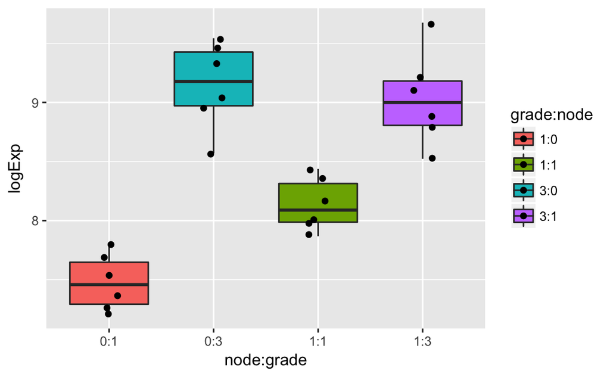

```r
library(ggplot2)
plot1 <- ggplot(kpna2, aes(x=node:grade, y=logExp,fill=grade:node))
plot2 <- ggplot(kpna2, aes(x=age, y=logExp,colour=grade:node))
plot3 <- ggplot(kpna2, aes(x=size, y=logExp,colour=grade:node))
plot1 +geom_boxplot(outlier.shape=NA) + geom_point(position=position_jitter(width=.1))
```

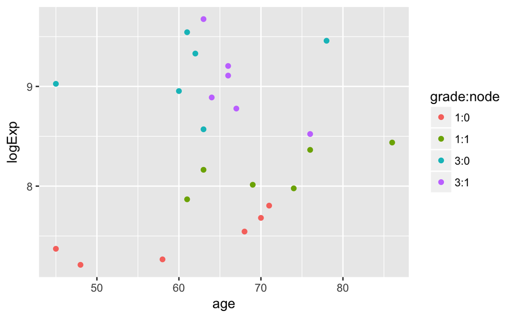

```r
plot2 + geom_point()
```

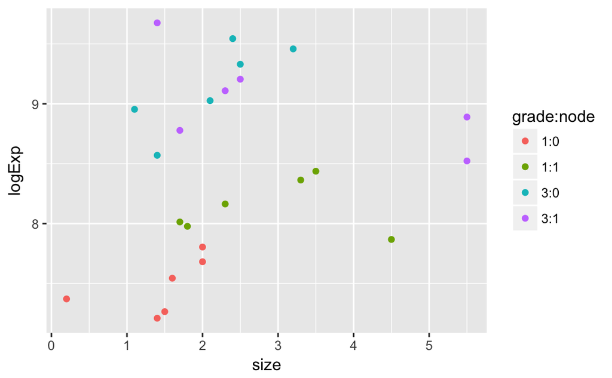

```r
plot3 + geom_point()
```

The plot suggests

- an effect of the histological grade
- an effect of node status
- The differential expression associated to grade seems to differ according to the lymph node status (interaction)

## 2.4. Hypotheses of interest

The researchers focus on the effect of the hystological grade, but because we expect a different effect in patients with irradicated nodes and unaffected nodes we will have to study the effect of hystological grade within patients with a certain node status.

Research questions:

- Is KPNA2 expression on average different between grade 3 and grade 1 in patients with unaffected lymph nodes
- Is KPNA2 expression on average different between grade 3 and grade 1 in patients with affected lymph nodes that were surgically removed
- Is the fold change of KPNA2 expression between grade 3 and grade 1 patients on average different according to the lymph node status? (interaction)

## 2.5. Model

Histologic grade and lymph node status can have an effect on the kpna2 gene. Moreover, it is also possible that the differential expression due to histological grade is differt in patients that have unaffected lymph nodes and patients for which the lymph nodes had to be removed. Hence, we will have to model the gene expression by using main effects for grade, node and a grade x node interaction.

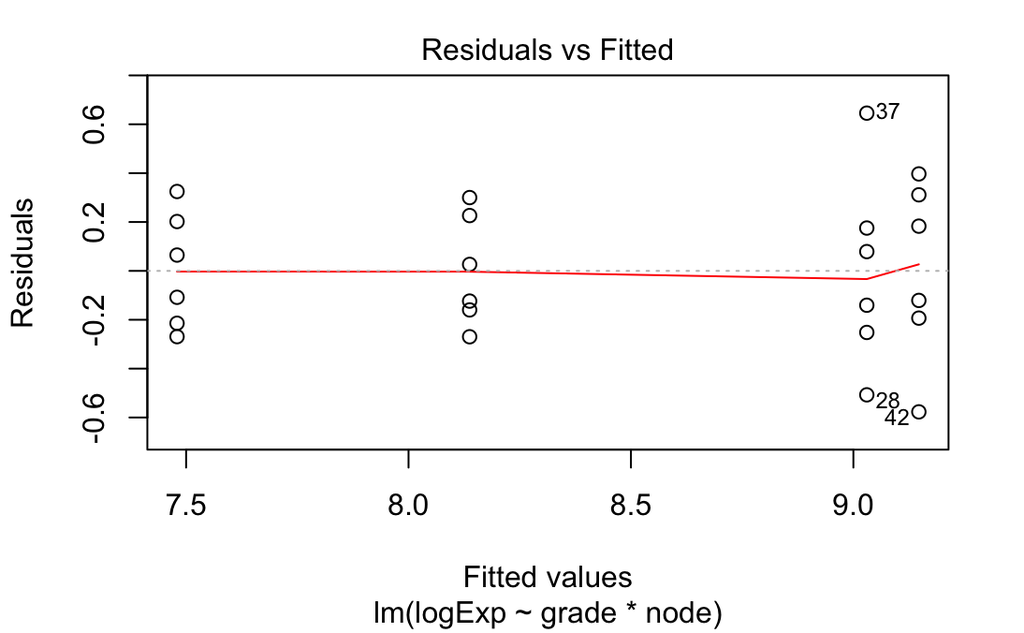

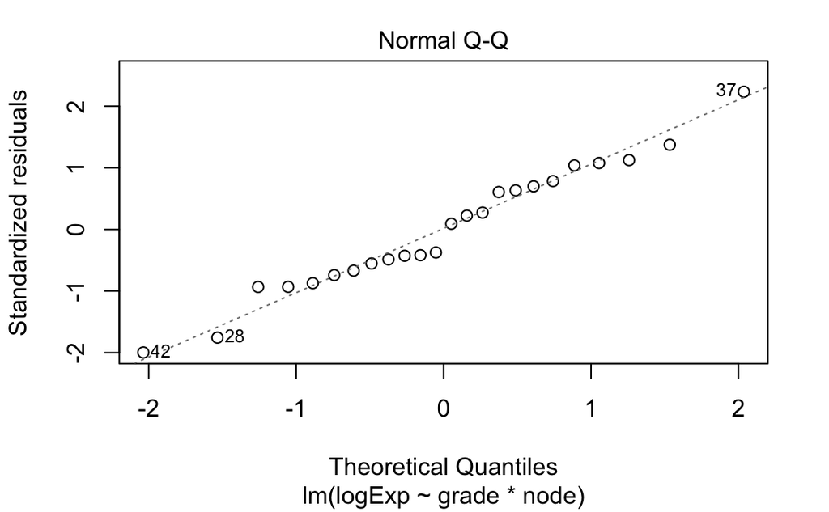

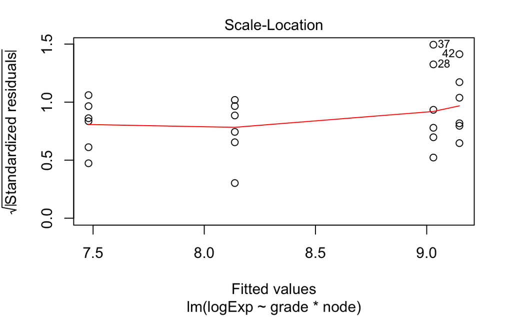

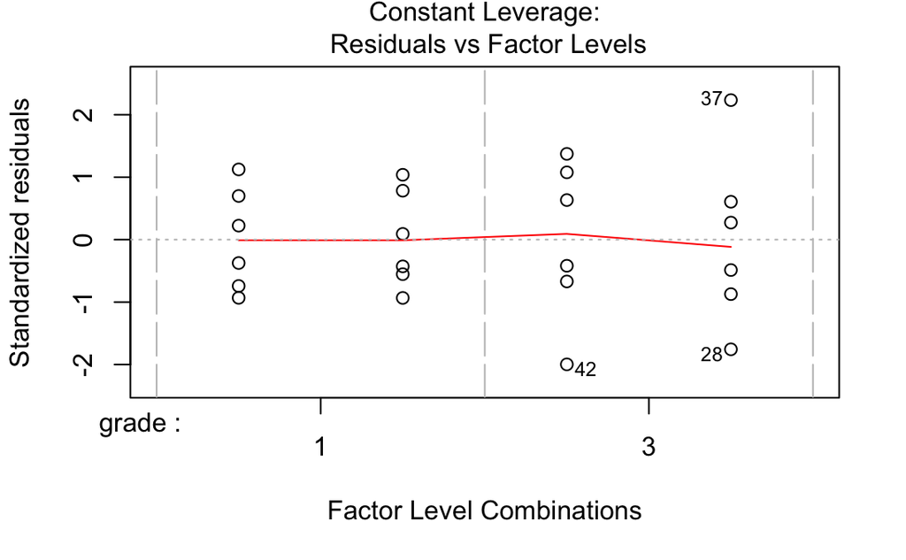

```r
#Adapt model!
fit <- lm(logExp~grade*node,data=kpna2)
plot(fit)
```

The variance is more or less equal for every treatment x node combination. The QQ-plot of the residuals shows no severe deviations from normality.

```r
summary(fit)
```

```
Call:
lm(formula = logExp ~ grade * node, data = kpna2)

Residuals:
     Min       1Q   Median       3Q
-0.57694 -0.19857 -0.04079  0.20807
     Max
 0.64557

Coefficients:
             Estimate Std. Error t value
(Intercept)    7.4796     0.1292  57.893
grade3         1.6675     0.1827   9.127
node1          0.6577     0.1827   3.600
grade3:node1  -0.7748     0.2584  -2.998
             Pr(>|t|)
(Intercept)   < 2e-16 ***
grade3       1.44e-08 ***
node1         0.00179 **
grade3:node1  0.00710 **
---
Signif. codes:
  0 '***' 0.001 '**' 0.01 '*' 0.05 '.'
  0.1 ' ' 1

Residual standard error: 0.3165 on 20 degrees of freedom
Multiple R-squared:  0.848, Adjusted R-squared:  0.8252
F-statistic: 37.18 on 3 and 20 DF,  p-value: 2.266e-08
```

```r
#Calculate confidence intervals for parameters of model
confint(fit)
```

```
                  2.5 %     97.5 %
(Intercept)   7.2101125  7.7491128
grade3        1.2864076  2.0486691
node1         0.2766005  1.0388620
grade3:node1 -1.3137511 -0.2357505
```

```r
#Transform parameters and the CI back to the original scale
2^fit$coef
```

```
 (Intercept)       grade3        node1
 178.4792627    3.1767209    1.5775997
grade3:node1
   0.5844896
```

```r
2^confint(fit)
```

```
                   2.5 %      97.5 %
(Intercept)  148.0676336 215.1371400
grade3         2.4391992   4.1372414
node1          1.2113372   2.0546063
grade3:node1   0.4022736   0.8492431
```

## 2.6. Interpretation of model parameters and statistical tests

We model the log$_2$-transformed intensities with the following model:
$$y=\beta_0+\beta_{g3}x_{g3}+\beta_{n1}x_{n1}+\beta_{g3n1}x_{g3}x_{n1},$$

with $\beta_0$ the intercept, $\beta_{g3}$ the main effect for grade, $x_{g3}$ a dummy variable for grade which is 0 for the control treatment in the absence of grade and 1 for the treatment with grade, $\beta_{n1}$ the main effect for node, $x_{n1}$ a dummy variable that is 0 for the measurements of patients with unaffected lymph nodes and 1 for patients for which the lymph nodes were removed and $\beta_{g3n1}$ the interaction effect between grade and node. To ease the interpertation of the parameters, $\log_2$ transformed mean intensities are given for each treatment group as well as corresponding contrasts between treatments, which have an interpretation in terms of $\log_2$ transformed fold changes (FC).

- $\log_2\hat{\mu}_{g1n0}=\hat\beta_0$, $\log_2 \hat{\mu}_{g3n0}=\hat\beta_0+\hat\beta_{g3}$ –> $\log_2 \widehat{FC}_{g3n0-g1n0}=\hat\beta_{g3}$
- $\log_2 \hat {\mu}_{g1n1}=\hat\beta_0+\hat\beta_t$, $\log_2 \hat{\mu}_{g3n1}=\hat\beta_0+\hat\beta_{g3}+\hat\beta_t+\hat\beta_{g3n1}$ –> $\log_2 \widehat{FC}_{g3n1-g1n1}=\hat \beta_{g3} +\hat\beta_{g3n1}$
- $\log_2 \widehat{FC}_{g1n1-g1n0}=\hat\beta_{n1}$, $\log_2 \widehat{FC}_{g3n1-g3n0}=\hat\beta_{n1}+\hat\beta_{g3n1}$ –> $\log_2\frac{\widehat{FC}_{g3n1-g1n1}}{\widehat{FC}_{g3n0-g1n0}}=\hat\beta_{g3n1}$

with $\log_2\hat \mu_{g1n0}$, $\log_2\hat \mu_{g3n0}$, $\log_2\hat \mu_{g1n1}$ and $\log_2\hat \mu_{g3n1}$ the estimated mean $\log_2$ transformed intensity for patients with grade 1 and node 0 status, grade 3 and node 0 status, grade 1 and node 1 status and grade 3 and node 1 status, respectively. With $\log_2 \widehat{FC}_{b-a}$ we indicate $\log_2$ transformed fold change estimates between treatment b and treatment a, i.e. $\log_2 \widehat{FC}_{b-a}=\log_2 \hat\mu_{b}-\log_2 \hat\mu_a=\log_2 \frac{\hat\mu_{b}}{\hat\mu_{a}}$.

The model immediately provides statistical tests for assessing the significance of fold changes between grade 3 and grade 1 for patients with unaffected lymph nodes (n=0) $\log_2 \widehat{FC}_{g3n0-g1n0}$, fold changes between the grade 1-node 1 patients and grade 1- node 0 patients $\log_2 \widehat{FC}_{g1n1-g3n0}$ and for differences in fold change due to histological grade for node 1 patients and node 0 patients. $\log_2\frac{\widehat{FC}_{g3n1-g1n1}}{\widehat{FC}_{g3n0-g1n0}}$, the interaction term.

```r
summary(fit)
```

```
Call:
lm(formula = logExp ~ grade * node, data = kpna2)

Residuals:
     Min       1Q   Median       3Q
-0.57694 -0.19857 -0.04079  0.20807
     Max
 0.64557

Coefficients:
             Estimate Std. Error t value
(Intercept)    7.4796     0.1292  57.893
grade3         1.6675     0.1827   9.127
node1          0.6577     0.1827   3.600
grade3:node1  -0.7748     0.2584  -2.998
             Pr(>|t|)
(Intercept)   < 2e-16 ***
grade3       1.44e-08 ***
node1         0.00179 **
grade3:node1  0.00710 **
---
Signif. codes:
  0 '***' 0.001 '**' 0.01 '*' 0.05 '.'
  0.1 ' ' 1

Residual standard error: 0.3165 on 20 degrees of freedom
Multiple R-squared:  0.848, Adjusted R-squared:  0.8252
F-statistic: 37.18 on 3 and 20 DF,  p-value: 2.266e-08
```

And confidence intervals

```r
CIfit<-confint(fit)
CIfit
```

```
                  2.5 %     97.5 %
(Intercept)   7.2101125  7.7491128
grade3        1.2864076  2.0486691
node1         0.2766005  1.0388620
grade3:node1 -1.3137511 -0.2357505
```

We can backtransform the parameters and confidence intervals to get estimates and CI for the Fold changes on the original scale

```r
2^coefficients(fit)
```

```
 (Intercept)       grade3        node1
 178.4792627    3.1767209    1.5775997
grade3:node1
   0.5844896
```

```r
2^CIfit
```

```
                   2.5 %      97.5 %
(Intercept)  148.0676336 215.1371400
grade3         2.4391992   4.1372414
node1          1.2113372   2.0546063
grade3:node1   0.4022736   0.8492431
```

## 2.7. Histological grade effect in patients with affected lymph nodes.

The researchers, however, are also interested in testing the significance of the fold change between patients with grade 3 and grade 1 tumors that had their lymph nodes removed. This involves assessing a contrast of the model parameters: $\log_2 \widehat{FC}_{g3n1-g1n1}=\hat \beta_{g3} +\hat\beta_{g3n1}$.

### 2.7.1. Test for contrast

With the multcomp package you can define contrasts, linear combinations of model parameters and assess if the contrast is statistically significant.

$$H_0: \mathbf{L}^T\boldsymbol{\beta}=0$$
vs
$$H_1: \mathbf{L}^T\boldsymbol{\beta}\neq 0,$$

with
$$L=\left[\begin{matrix}0\\1\\0\\1\end{matrix}\right] \text{and } \boldsymbol{\beta}=\left[\begin{matrix}\beta_0\\\beta_{g3}\\\beta_{n1}\\\beta_{g3n1}\end{matrix}\right]$$
for the contrast of interest.

In R, we can either use a vector L or define a formula using the parameter names. We first illustrate the latter.

```r
library(multcomp)
contrast <- glht(fit, linfct = c("grade3 +grade3:node1 = 0"))
summary(contrast)
```

```
     Simultaneous Tests for General Linear Hypotheses

Fit: lm(formula = logExp ~ grade * node, data = kpna2)

Linear Hypotheses:
                           Estimate
grade3 + grade3:node1 == 0   0.8928
                           Std. Error
grade3 + grade3:node1 == 0     0.1827
                           t value
grade3 + grade3:node1 == 0   4.886
                           Pr(>|t|)
grade3 + grade3:node1 == 0 8.93e-05 ***
---
Signif. codes:
  0 '***' 0.001 '**' 0.01 '*' 0.05 '.'
  0.1 ' ' 1
(Adjusted p values reported -- single-step method)
```

```r
confint(contrast)
```

```
     Simultaneous Confidence Intervals

Fit: lm(formula = logExp ~ grade * node, data = kpna2)

Quantile = 2.086
95% family-wise confidence level


Linear Hypotheses:
                           Estimate lwr
grade3 + grade3:node1 == 0 0.8928   0.5117
                           upr
grade3 + grade3:node1 == 0 1.2739
```

We can also define the vector ourself.

```r
L<-matrix(nrow=length(coef(fit)),ncol=1,0)
rownames(L) <-names(coef(fit))
colnames(L) <-"contrast1"
L[grepl(rownames(L),pattern="grade3"),1] <- 1
L
```

```
             contrast1
(Intercept)          0
grade3               1
node1                0
grade3:node1         1
```

and assess the significance of the contrast by

```r
contrastVec <- glht(fit, linfct = t(L))
summary(contrastVec)
```

```
     Simultaneous Tests for General Linear Hypotheses

Fit: lm(formula = logExp ~ grade * node, data = kpna2)

Linear Hypotheses:
               Estimate Std. Error t value
contrast1 == 0   0.8928     0.1827   4.886
               Pr(>|t|)
contrast1 == 0 8.93e-05 ***
---
Signif. codes:
  0 '***' 0.001 '**' 0.01 '*' 0.05 '.'
  0.1 ' ' 1
(Adjusted p values reported -- single-step method)
```

### 2.7.2. Confidence intervals FC for effect of grade in patients with removed lymph nodes.

```r
CIFCg3n1_g1n1 <- confint(contrastVec)
CIFCg3n1_g1n1
```

```
     Simultaneous Confidence Intervals

Fit: lm(formula = logExp ~ grade * node, data = kpna2)

Quantile = 2.086
95% family-wise confidence level


Linear Hypotheses:
               Estimate lwr    upr
contrast1 == 0 0.8928   0.5117 1.2739
```

Backtransform to FC

```r
2^CIFCg3n1_g1n1$confint
```

```
          Estimate      lwr      upr
contrast1  1.85676 1.425686 2.418174
attr(,"conf.level")
[1] 0.95
attr(,"calpha")
[1] 2.085963
```

The histological grade effect in patients with affected lymph nodes is also extremely significant (p<<0.001). The expression of the kpna2 gene in patients with affected lymph nodes is on average 1.86 times higher in patients with a histological grade 3 tumor than in patients with histological grade 1 tumor. (95% CI [1.43, 2.42]).

## 2.8. Assess all hypotheses of interest and correct for multiple testing

You can also define multiple contrasts and assess them simultaneously, then the multcomp package will automatically adjust for multiple testing.

```r
L<-matrix(nrow=length(coef(fit)),ncol=3,0)
rownames(L) <-names(coef(fit))
colnames(L) <-paste0("contrast",1:3)
L["grade3",1]<-1
L[grepl(rownames(L),pattern="grade3"),2] <- 1
L["grade3:node1",3]<-1
L
```

```
             contrast1 contrast2 contrast3
(Intercept)          0         0         0
grade3               1         1         0
node1                0         0         0
grade3:node1         0         1         1
```

Complete the analysis for all contrasts!

# 3. Conclusions

# 4. Redo the analysis by coding the linear regression analysis yourself using matrices.

## 4.1. Fit

## 4.2. Standard errors

## 4.3. Inference with contrasts